# Tutorial single-cell RNA-seq analysis

Jonas Schulte-Schrepping

July 18th, 2019

# Introduction

This practical will perform some of the initial steps in a basic scRNA-seq data analysis, including:

- Quality control on the cells
- Normalization
- Modelling technical noise
- Dimensionality reduction
- Some visualization and clustering

In this tutorial we will mainly use the R package **Seurat**, but there are plenty of alternative packages available, e.g.:

- scater
- scran
- simpleSingleCell (very good and comprehensive tutorial for single-cell RNA-seq analysis),

on Bioconductor that perform similar tasks.

Additional tutorials on single-cell RNA-seq analysis can be found here:

- A step-by-step workflow for low-level analysis of single-cell RNA-seq data with Bioconductor [link](https://f1000research.com/articles/5-2122/v2)
- Orchestrating Single-Cell Analysis with Bioconductor [link](https://www.biorxiv.org/content/10.1101/590562v1)
- Analysis of single cell RNA-seq data [link](https://scrnaseq-course.cog.sanger.ac.uk/website/index.html) | [youtube](https://www.youtube.com/channel/UCsc6r6UKxb2qRcDQPix2L5A)

A very comprehensive list of available software packages for single-cell genomics analyses can be found [here](https://github.com/seandavi/awesome-single-cell).

[Seurat](https://satijalab.org/seurat/) is an R package developed and maintained by the Satija lab at NYU, in particular by Andrew Butler, Paul Hoffman, Tim Stuart, Christoph Hafemeister, and Shiwei Zheng, designed for QC, analysis, and exploration of single-cell RNA-seq data. Seurat aims to enable users to identify and interpret sources of heterogeneity from single-cell transcriptomic measurements, and to integrate diverse types of single-cell data.

Seurat features three computational methods for single cell analysis:

1. Unsupervised clustering and discovery of cell types and states (Macosko, Basu, Satija et al., Cell, 2015)
2. Spatial reconstruction of single-cell data (Satija, Farrell et al., Nature Biotechnology, 2015)
3. Integrated analysis of single-cell RNA-seq across conditions, technologies, and species (Butler et al., Nature Biotechnology, 2018)

All methods emphasize clear, attractive, and interpretable visualizations, and were designed to be easily used by both dry-lab and wet-lab researchers.

In this tutorial, we will focus on the first method and follow a comprehensive [tutorial](https://satijalab.org/seurat/v3.0/pbmc3k_tutorial.html) provided by the Satija lab.

We will be analyzing a 3’-targeted scRNA-seq dataset of Peripheral Blood Mononuclear Cells (PBMC) freely available from 10X Genomics [here](https://support.10xgenomics.com/single-cell-gene-expression/datasets/3.0.0/pbmc_1k_v3).

We download the Feature/cell matrix (filtered) archive, and extract the folder *filtered_feature_bc_matrix* containing the **zipped** files:

- features.tsv.gz
- barcodes.tsv.gz
- matrix.mtx.gz

The raw data has been processed by 10x using their pre-processing software suite [Cellranger](https://support.10xgenomics.com/single-cell-gene-expression/software/pipelines/latest/what-is-cell-ranger) 3.0.0.

- 1,222 cells detected
- Sequenced on Illumina NovaSeq with approximately 54,000 reads per cell
- 28bp read1 (16bp Chromium barcode and 12bp UMI), 91bp read2 (transcript), and 8bp I7 sample barcode
- run with –expect-cells=1000

We are on purpose not using the [data set](https://s3-us-west-2.amazonaws.com/10x.files/samples/cell/pbmc3k/pbmc3k_filtered_gene_bc_matrices.tar.gz) used in the official Seurat tutorial, so that you can redo the analysis with that data set and compare the results.

# Install packages

Please uncomment and execute the following three chunks **once** before you start the analysis. After successful installation, please comment them out again and make sure that the packages are loaded using the library() function (see chunks below!)

## Cran

```r
# install.packages(c("Seurat",
#                   "dplyr",
#                   "devtools",
#                   "reshape2",
#                   "ggplot2"))
```

# Load packages

```r
library(devtools)
library(dplyr)
library(ggplot2)
library(reshape2)
library(Seurat)
```

# Load the data

We start by reading the data. From the github repository you downloaded an archive called *pbmc_1k_v3_filtered_feature_bc_matrix.tar.gz*. Please unzip the archive (**twice**) to get a directory *filtered_feature_bc_matrix* containing the zipped files (features.tsv.gz, barcodes.tsv.gz, matrix.mtx.gz) in the same directory as your .Rmd file.

The Read10X function reads in the output of the cellranger pipeline from 10X, returning a unique molecular identified (UMI) count matrix. The values in this matrix represent the number of molecules for each feature (i.e. gene; row) that are detected in each cell (column).

```r
# Load the PBMC dataset
pbmc.data <- Read10X(data.dir = "filtered_feature_bc_matrix")
```

Single-cell RNA-seq data can easily become very big and might overcharge your machine’s memory resources. Therefore, all features in Seurat have been configured to work with sparse matrices which results in significant memory and speed savings.

What is the size of the data stored as a regular matrix?

```r
dense.size <- object.size(x = as.matrix(x = pbmc.data))
dense.size
```

```
## 330240352 bytes
```

What is the size of the data stored as a sparce matrix?

```r
sparse.size <- object.size(x = pbmc.data)
sparse.size
```

```
## 32357568 bytes
```

```r
dense.size/sparse.size
```

```
## 10.2 bytes
```

# Inspection of count matrix

```r
pbmc.data[1:5,1:3]
```

```
## 5 x 3 sparse Matrix of class "dgCMatrix"
##             AAACCCAAGGAGAGTA AAACGCTTCAGCCCAG AAAGAACAGACGACTG
## MIR1302-2HG                .                .                .
## FAM138A                    .                .                .
## OR4F5                      .                .                .
## AL627309.1                 .                .                .
## AL627309.3                 .                .                .
```

```r
dim(pbmc.data)
```

```
## [1] 33538  1222
```

Exclude genes with 0 counts

```r
pbmc.data <- pbmc.data[rowSums(as.matrix(pbmc.data))>0,]
```

Dimensions of the count table after filtering of genes with 0 counts

```r
dim(pbmc.data)
```

```
## [1] 18391  1222
```

Percentage of 0 in the data

```r
paste(round((sum(pbmc.data==0)/(nrow(pbmc.data)*ncol(pbmc.data)))*100,2), " %",sep="")
```

```
## [1] "88.88 %"
```

## Present gene types

Load gene annotation

```r
bm <- read.delim("biomart_table.txt", header= TRUE, stringsAsFactors = FALSE,sep = "\t")
```

This table has been produced using the following code:

```r
# if (!requireNamespace("BiocManager", quietly = TRUE))
#     install.packages("BiocManager")
#
# BiocManager::install(c("biomaRt","org.Hs.eg.db"))
#
# library(biomaRt)
# library(org.Hs.eg.db)
#
# # Access ensembl data base and download relevant information:
# ensembl <- useMart("ensembl",
#                    dataset="hsapiens_gene_ensembl") # needs internet connection!
#
# # Download selected attributes:
# bm <- getBM(attributes = c("ensembl_gene_id",
#                            "external_gene_name",
#                            "description",
#                            "gene_biotype",
#                            "chromosome_name"),
#             mart = ensembl)
#
# head(bm)
```

Plot the expression of all genes according to gene types:

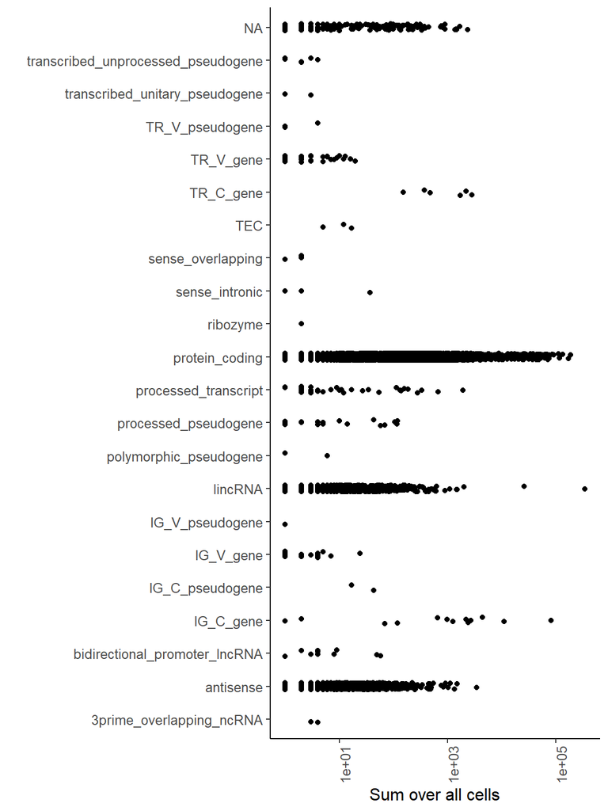

```r
GeneTypeExpr <- function(input){
  counts <- as.matrix(input)
  IDX <- match(rownames(counts), bm$external_gene_name)
  genetypeexpr <- data.frame(SYMBOL=rownames(counts),
                             TYPE=bm$gene_biotype[IDX],
                             MEAN=rowMeans(counts),
                             SUM=rowSums(counts))

  ggplot(genetypeexpr,aes(x=TYPE,y=SUM))+
    geom_jitter(height = 0, width = 0.1)+
    scale_y_log10()+
    ylab("Sum over all cells") +
    xlab("")+
    theme_classic() +
    coord_flip()+
    theme(text = element_text(size=12),legend.position="none", axis.text.x = element_text(angle = 90, hjust = 1))
}

GeneTypeExpr(input=pbmc.data)
```

We observe quite a high number of genes that are not assigned to known gene types. This is due to the inconsistencies in public gene annotation data bases. Unfortunately, we do not know exactly which annotation has been used by 10x during the pre-processing of this data set, which prevents exact mapping of the gene symbols to gene types.

## Highest expressed genes

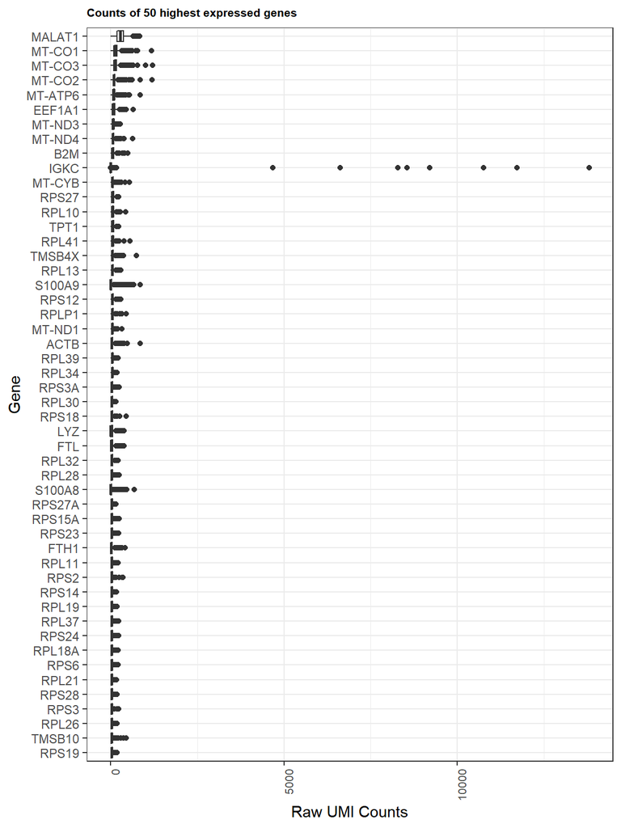

```r
highestGenes <- function(input,
                         numGenes=50){
  tmp <- as.matrix(input)
  tmp <- tmp[order(rowSums(tmp), decreasing = T),]
  tmp <- tmp[1:numGenes,]
  tmp <- melt(t(tmp))
  colnames(tmp)<- c("sample","gene","value")
  tmp$gene <- factor(tmp$gene, levels = rev(unique(tmp$gene)))

  ggplot(tmp, aes(x = tmp$gene, y = value)) +
      geom_boxplot()+
      scale_y_continuous()+
      xlab("Gene")+
      ylab("Raw UMI Counts")+
      ggtitle(paste("Counts of", numGenes, "highest expressed genes")) +
      theme_bw() +
      coord_flip() +
      theme(axis.text.x = element_text(size=8, angle = 90, hjust = 1),
            plot.title = element_text(size = 8, face = "bold"))
}

highestGenes(input=pbmc.data,
             numGenes =50)
```

**What are all these RPL and RPS genes?**

Depending on the tissue and the cell type, the expression of ribosomal protein-coding genes can be very high. Accoring to 10x, the fraction of reads mapping to ribosomal proteins can be as high as 35-40% in human PBMCs [(Ref.)](https://kb.10xgenomics.com/hc/en-us/articles/218169723-What-fraction-of-reads-map-to-ribosomal-proteins-)!

### Percentage of counts from certain gene families of all counts per cell

```
## [1] "25.77 % of all counts come from ^RPL|^RPS genes"
```

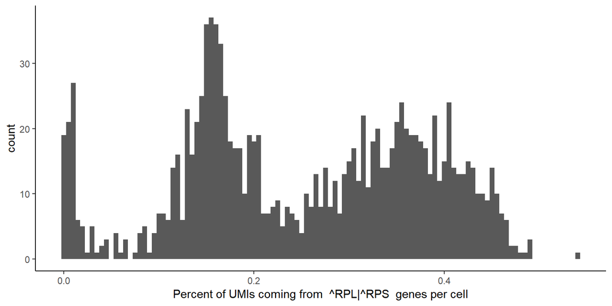

```r
percentofCountsperCell <- function(input,
                                   pattern){
  input <- as.matrix(input)
  tmp <- sum(input[grep(pattern = pattern, rownames(input), value = TRUE),])
  sum_counts <- sum(colSums(input))
  print(paste(round(tmp/sum_counts*100,2)," % of all counts come from ",pattern," genes",sep=""))

  features <- grep(pattern = pattern, rownames(input), value = TRUE)
  percent <- colSums(input[features,])/colSums(input)

  data <- data.frame(percent=percent,
                    cell=names(percent))

  ggplot(data, aes(percent)) +
    geom_histogram(binwidth = 0.005)+
    xlab(paste("Percent of UMIs coming from ", pattern," genes per cell")) +
    theme_classic()
}

percentofCountsperCell(input=pbmc.data,
                       pattern="^RPL|^RPS")
```

# Standard pre-processing workflow

The steps below encompass the standard pre-processing workflow for scRNA-seq data in Seurat, e.g.,

1. the creation of a Seurat object,
2. the selection and filtration of cells based on QC metrics,
3. data normalization and scaling, and
4. the detection of highly variable genes.

## Initialize the Seurat Object

We use the count matrix to create a Seurat object. The object serves as a container that contains both data (like the count matrix) and analysis (like PCA, or clustering results) for a single-cell dataset. For a technical discussion of the Seurat object structure, check out our GitHub Wiki. For example, the count matrix is stored in pbmc[[“RNA”]]@counts.

```r
pbmc <- CreateSeuratObject(counts = pbmc.data,
                           min.cells = 3,
                           min.features = 200,
                           project = "10X_PBMC")

pbmc
```

```
## An object of class Seurat
## 15246 features across 1176 samples within 1 assay
## Active assay: RNA (15246 features)
```

# Let’s have a look at the raw data

Seurat v3 has so-called accession functions build in that allow you to easily access the data stored within the seurat object without manually navigating through the object.

```r
GetAssayData(object = pbmc, slot = 'counts')[1:10,1:3]
```

```
## 10 x 3 sparse Matrix of class "dgCMatrix"
##            AAACCCAAGGAGAGTA AAACGCTTCAGCCCAG AAAGAACAGACGACTG
## AL627309.1                .                .                .
## AL669831.5                .                .                .
## LINC00115                 .                .                .
## FAM41C                    .                .                .
## NOC2L                     .                .                .
## KLHL17                    .                .                .
## PLEKHN1                   .                .                .
## AL645608.8                .                .                .
## HES4                      .                .                .
## ISG15                     .                1                .
```

# Quality control and selecting cells for further analysis

While the CreateSeuratObject imposes a basic minimum gene-cutoff, you may want to filter out cells at this stage based on technical or biological parameters.

Seurat allows you to easily explore QC metrics and filter cells based on any user-defined criteria. A few QC metrics commonly used by the community include

- The number of unique genes detected in each cell.
  - Low-quality cells or empty droplets will often have very few genes
  - Cell doublets or multiplets may exhibit an aberrantly high gene count
- Similarly, the total number of molecules detected within a cell (correlates strongly with unique genes)
- The percentage of reads that map to the mitochondrial genome
  - Low-quality/dying cells often exhibit extensive mitochondrial contamination
  - We calculate mitochondrial QC metrics with the PercentageFeatureSet function, which calculates the percentage of counts originating from a set of features
  - We use the set of all genes starting with MT- as a set of mitochondrial genes

Importantly, the percentage of mitochondrial reads can vary substantially between different cell types or cells of different tissues. Furthermore, the scRNA-seq technique as well as the pre-processing can have a big influence on this metric, e.g. standard 10X CellRanger excludes mitochondrial rRNAs among many others from the counting process during the pre-processing [(Ref.)](https://support.10xgenomics.com/single-cell-gene-expression/software/pipelines/latest/advanced/references), which greatly reduces these reads in the count matrix. In conclusion, the user has to **carefully choose a data set-specific cut-off** for this metric!

```r
pbmc[["percent.mt"]] <- PercentageFeatureSet(pbmc, pattern = "^MT-")
```

**Where are QC metrics stored in Seurat?**

- The number of unique genes and total molecules are automatically calculated during CreateSeuratObject
  - You can find them stored in the object meta data

```r
# Show QC metrics for the first 5 cells
head(pbmc@meta.data, 5)
```

|  | orig.ident | nCount_RNA | nFeature_RNA | percent.mt |
| --- | --- | --- | --- | --- |
| AAACCCAAGGAGAGTA | 10X_PBMC | 8286 | 2618 | 10.777215 |
| AAACGCTTCAGCCCAG | 10X_PBMC | 5509 | 1805 | 7.968778 |
| AAAGAACAGACGACTG | 10X_PBMC | 4280 | 1559 | 6.191589 |
| AAAGAACCAATGGCAG | 10X_PBMC | 2754 | 1225 | 5.991285 |
| AAAGAACGTCTGCAAT | 10X_PBMC | 6589 | 1828 | 6.617089 |

**Mean number of UMI per cell:** 7818

**Mean number of genes per cell:** 2119

In the example below, we visualize QC metrics, and use these to filter the cells and get rid of background noise.

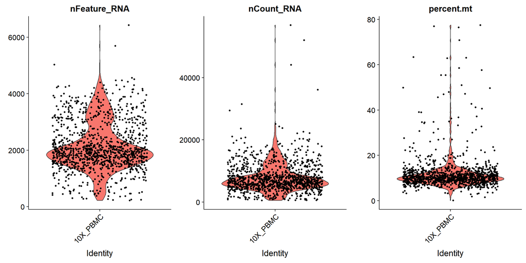

```r
# Visualize QC metrics as a violin plot
VlnPlot(pbmc, features = c("nFeature_RNA", "nCount_RNA", "percent.mt"), ncol = 3)
```

Here, we plot the number of genes per cell by what Seurat calls ‘orig.ident’. Identity is a concept that is used in the Seurat object to refer to the cell’s identity. In this case, the cell’s identity is 10X_PBMC. After we cluster the cells, the identity will be the cluster the cell belongs to. We will see how the identity updates as we go throught the analysis.

Another helpful function to visualize the quality of the data is the FeatureScatter() function. It is typically used to visualize feature-feature relationships, but can be used for anything calculated by the object, i.e. columns in object meta.data, PC scores etc.  
Here, the plot helps to identify a rare subset of cells with an outlier level of high mitochondrial percentage and also low UMI content, which we could exclude from the data.

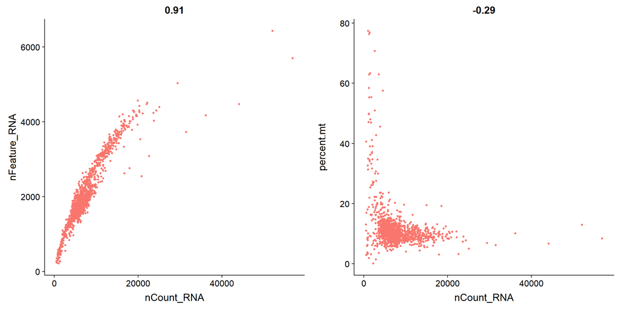

```r
plot1 <- FeatureScatter(pbmc, feature1 = "nCount_RNA", feature2 = "nFeature_RNA")+NoLegend()
plot2 <- FeatureScatter(pbmc, feature1 = "nCount_RNA", feature2 = "percent.mt")+NoLegend()

CombinePlots(plots = list(plot1, plot2))
```

We want to exclude cells that have very high or low unique gene counts, indicating potential dublets or “empty” barcodes. Note that the parameters low.thresholds and high.thresholds are used to define a ‘gate’. -Inf and Inf should be used if you don’t want a lower or upper threshold.

Furthermore, we can exclude cells with a high percentage of mitochondrial reads, indicating cell death (at least for some cells).

Task: Set the thresholds to what you think they should be according to the violin plots by replacing the stars with reasonable numbers.

```r
pbmc <- subset(pbmc, subset = nFeature_RNA > 200 & nFeature_RNA < 5000 & percent.mt < 20)
```

How many cells are you left with?

```r
dim(pbmc)
```

```
## [1] 15246  1110
```

Compare with previous plots:

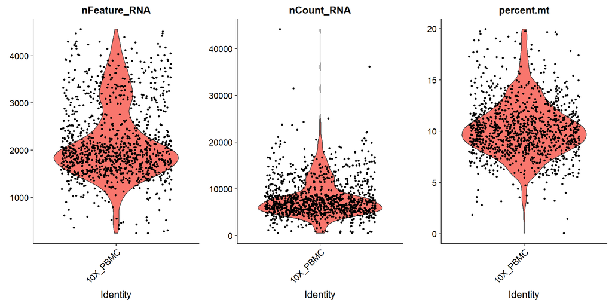

```r
VlnPlot(pbmc, features = c("nFeature_RNA", "nCount_RNA", "percent.mt"), ncol = 3)
```

# Normalizing the data

After removing unwanted cells from the dataset, the next step is to normalize the data. By default, we employ a global-scaling normalization method “LogNormalize” that normalizes the gene expression measurements for each cell by the total expression, multiplies this by a scale factor (10,000 by default), and log-transforms the result.

```r
pbmc <- NormalizeData(pbmc,
                      normalization.method = "LogNormalize",
                      scale.factor = 10000)
```

Recently, a number of alternative normalization strategies have been published that use more sophisticated methods for the normalization of scRNA-seq data, e.g.:

- [SCnorm](https://www.nature.com/articles/nmeth.4263)
- [scTransform](https://www.biorxiv.org/content/10.1101/576827v2)

# Identification of highly variable features (feature selection)

Next, we calculate a subset of features that exhibit high cell-to-cell variation in the dataset (i.e, they are highly expressed in some cells, and lowly expressed in others). Focusing on these genes in downstream analysis helps to highlight biological signal in single-cell datasets.

The procedure in Seurat v3 is described in detail [here](https://www.biorxiv.org/content/early/2018/11/02/460147.full.pdf), and improves on previous versions by directly modeling the mean-variance relationship inherent in single-cell data, and is implemented in the FindVariableFeatures function. By default, the function returns 2,000 features per dataset. These will be used in downstream analysis, like PCA.

```
## When using repel, set xnudge and ynudge to 0 for optimal results
```

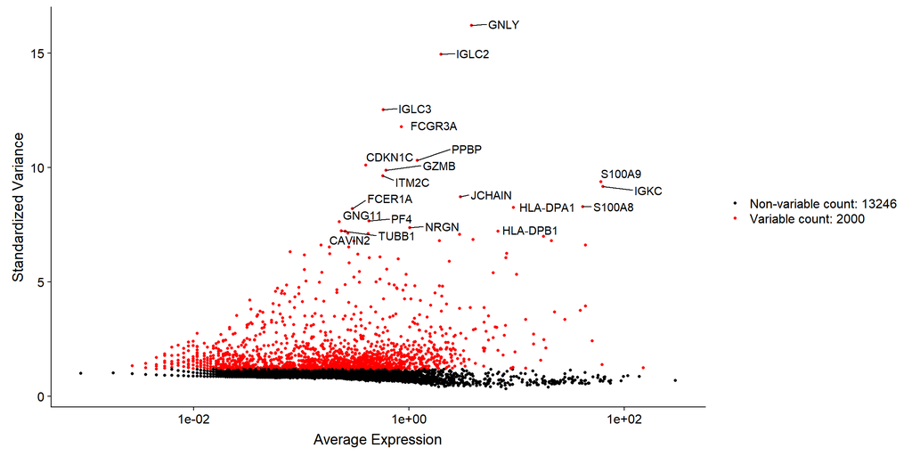

```r
pbmc <- FindVariableFeatures(pbmc, selection.method = "vst", nfeatures = 2000)

# Identify the 10 most highly variable genes
top20 <- head(VariableFeatures(pbmc), 20)

# plot variable features with and without labels
LabelPoints(plot = VariableFeaturePlot(pbmc), points = top20, repel = TRUE)
```

# Scaling the data and removing unwanted sources of variation

Your single cell dataset likely contains ‘uninteresting’ sources of variation. This could include not only technical noise, but batch effects, or even biological sources of variation (cell cycle stage). As suggested in Buettner et al, Nature Biotech, 2015, regressing these signals out of the analysis can improve downstream dimensionality reduction and clustering. To mitigate the effect of these signals, Seurat constructs linear models to predict gene expression based on user-defined variables. The scaled z-scored residuals of these models are stored in the scale.data slot, and are used for dimensionality reduction and clustering.

The ScaleData function:

- Shifts the expression of each gene, so that the mean expression across cells is 0
- Scales the expression of each gene, so that the variance across cells is 1 + This step gives equal weight in downstream analyses, so that highly-expressed genes do not dominate
- The results of this are stored in pbmc[[“RNA”]]@scale.data

```r
all.genes <- rownames(pbmc)
pbmc <- ScaleData(pbmc, features = all.genes)
```

# Perform dimensionality reduction

Next, we perform PCA on the scaled data. By default, only the previously determined variable features are used as input, but can be defined using the features argument if you wish to choose a different subset. Typically, running dimensionality reduction on highly variable genes can improve performance. However, with UMI data - particularly after regressing out technical variables, we often see that PCA returns similar (albeit slower) results when run on much larger subsets of genes, including the whole transcriptome.

```r
pbmc <- RunPCA(pbmc,
               features = VariableFeatures(object = pbmc))
```

```
## PC_ 1
## Positive:  LYZ, FCN1, S100A9, FGL2, MNDA, CST3, CTSS, S100A8, SERPINA1, VCAN
##     NCF2, PSAP, AIF1, TYMP, CSTA, KLF4, GRN, CD68, MPEG1, CLEC7A
##     LST1, TNFAIP2, MS4A6A, CPVL, CYBB, CD14, SLC7A7, LGALS1, S100A12, FTL
## Negative:  LTB, CD3E, TRAC, TRBC2, LCK, CD3D, IL32, IL7R, TCF7, CD3G
##     CD69, ISG20, CD27, CD247, SPOCK2, ARL4C, CD7, CD2, LAT, BCL11B
##     GZMM, TRBC1, NOSIP, CD6, RORA, RARRES3, SYNE2, ZAP70, CTSW, CCR7
## PC_ 2
## Positive:  CD3E, IL32, CD247, GZMM, LCK, CTSW, CD7, CD3D, ANXA1, S100A4
##     GZMA, NKG7, CD3G, RARRES3, CST7, PRF1, TRAC, LAT, IL7R, KLRB1
##     ARL4C, RORA, ZAP70, CD2, CCL5, KLRG1, TRBC1, SAMD3, ITGB2, SYNE2
## Negative:  CD79A, MS4A1, IGHM, BANK1, HLA-DQA1, CD79B, LINC00926, HLA-DQB1, IGHD, CD22
##     CD74, HLA-DRB1, TNFRSF13C, SPIB, HLA-DRA, HLA-DQA2, HLA-DPA1, HLA-DPB1, TCL1A, BCL11A
##     RALGPS2, FAM129C, HLA-DRB5, FCER2, IGKC, VPREB3, MEF2C, FCRL1, HVCN1, FCRLA
## PC_ 3
## Positive:  CAVIN2, GNG11, TUBB1, PF4, GP9, PPBP, TREML1, CD9, SPARC, CLU
##     CMTM5, PTCRA, HIST1H2AC, GMPR, MTURN, ANKRD9, PRKAR2B, CTTN, C2orf88, GFI1B
##     TMEM40, ACRBP, NRGN, ITGA2B, CLDN5, SMOX, SNCA, PGRMC1, ESAM, GP1BA
## Negative:  MT-CO1, CYBA, FOSB, FOS, VIM, ITGB2, NEAT1, DUSP1, HNRNPU, LCP1
##     S100A10, LSP1, PRELID1, CD74, S100A6, CALR, KLF6, LTB, ZFP36L1, EVI2B
##     MCL1, S100A4, SPCS1, ISG20, PLAC8, IFITM2, ANXA1, AC007952.4, SEC61B, MYO1F
## PC_ 4
## Positive:  LEF1, MAL, TCF7, TRABD2A, RCAN3, IL7R, CCR7, NOSIP, CD3D, LTB
##     TRAC, CAMK4, CD3G, PASK, NELL2, CD27, BCL11B, CD5, RGS10, SLC2A3
##     TSHZ2, FHIT, ACTN1, RGCC, EGR1, LINC01550, CD40LG, VIM, CD6, ADTRP
## Negative:  GZMB, CLIC3, GNLY, NKG7, KLRD1, KLRF1, PRF1, CST7, SPON2, FGFBP2
##     GZMA, ADGRG1, HOPX, CCL4, TRDC, TTC38, MATK, TBX21, APOBEC3G, IL2RB
##     CTSW, C12orf75, APMAP, RHOC, FCGR3A, CD160, S1PR5, SH2D1B, CMC1, PTGDR
## PC_ 5
## Positive:  SERPINF1, LILRA4, SMPD3, CLEC4C, SCT, LRRC26, IL3RA, AL096865.1, PACSIN1, TPM2
##     DNASE1L3, NOTCH4, TNFRSF21, GAS6, DERL3, CIB2, NRP1, RHEX, CUX2, MYBL2
##     SCN9A, ITM2C, UGCG, PLD4, PPP1R14B, LINC00996, NAT8L, PPM1J, ZFAT, SERPINF2
## Negative:  GNLY, KLRD1, FGFBP2, KLRF1, ADGRG1, PRF1, CST7, NKG7, CCL4, HOPX
##     TRDC, GZMA, CD79B, LINC00926, MS4A1, TBX21, SPON2, IGHD, MATK, CD79A
##     TTC38, IL2RB, CD160, CD22, MYOM2, S1PR5, SH2D1B, APOBEC3G, FCER2, GZMH
```

Seurat provides several useful ways of visualizing both cells and features that define the PCA, including VizDimReduction, DimPlot, and DimHeatmap

Visualize top genes that are associated with principal components 1 to 5.

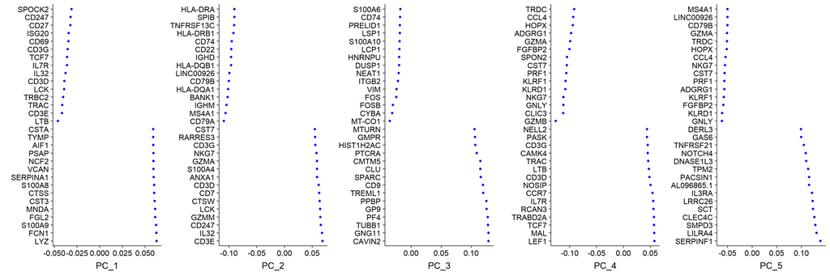

```r
VizDimLoadings(pbmc, dims = 1:5, reduction = "pca", balanced=TRUE,ncol = 5)
```

Plot principal components 1 and 2 in a scatterplot. Every dot represents a cell.

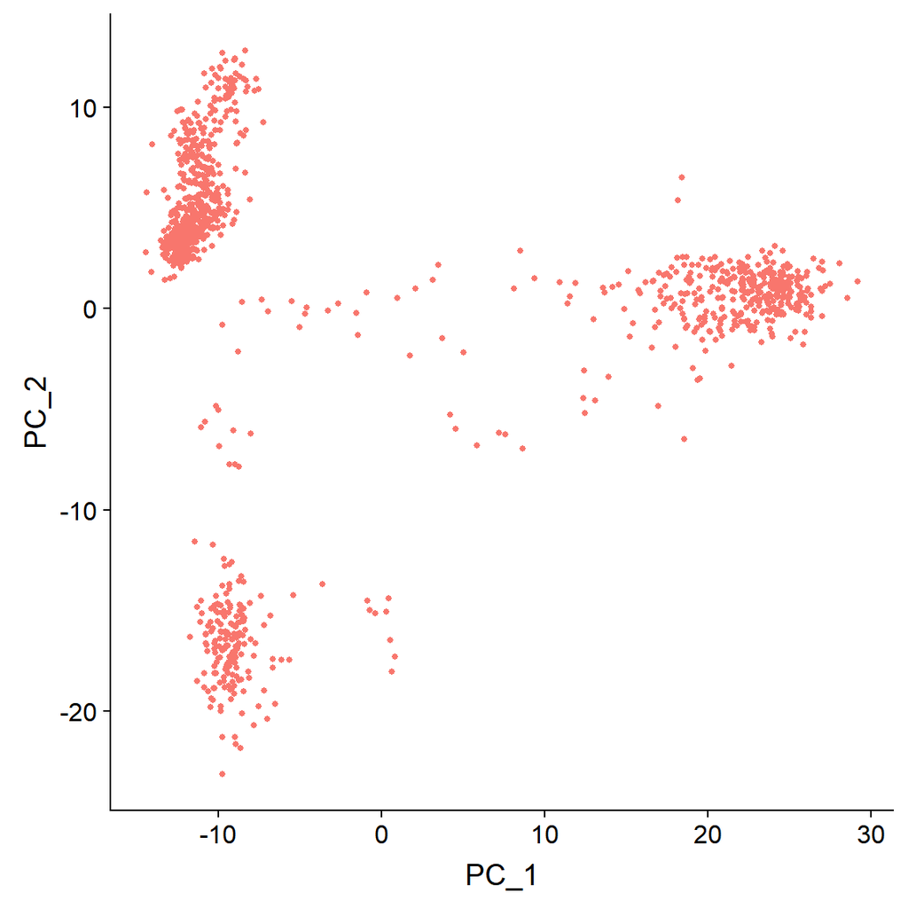

```r
DimPlot(pbmc, reduction = "pca",dims = c(1,2))+NoLegend()
```

In particular DimHeatmap allows for easy exploration of the primary sources of heterogeneity in a dataset, and can be useful when trying to decide which PCs to include for further downstream analyses. Both cells and features are ordered according to their PCA scores. Setting ‘cells’ to a certain number plots the ‘extreme’ cells on both ends of the spectrum, which dramatically speeds plotting for large datasets. Though clearly a supervised analysis, we find this to be a valuable tool for exploring correlated feature sets.

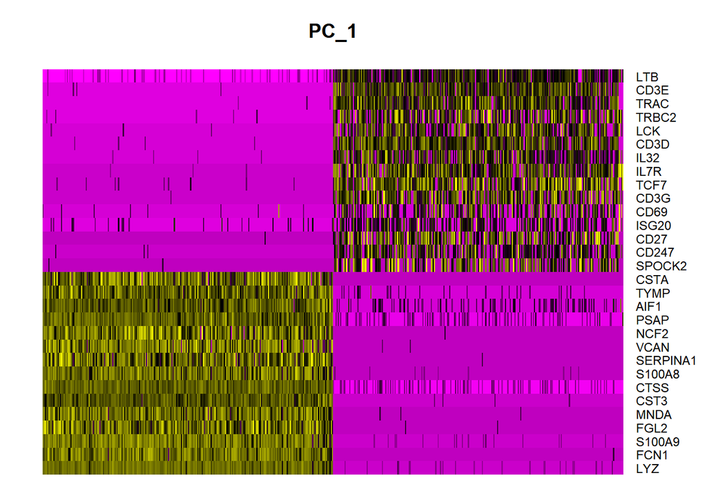

```r
DimHeatmap(pbmc, dims = 1, cells = 500, balanced = TRUE)
```

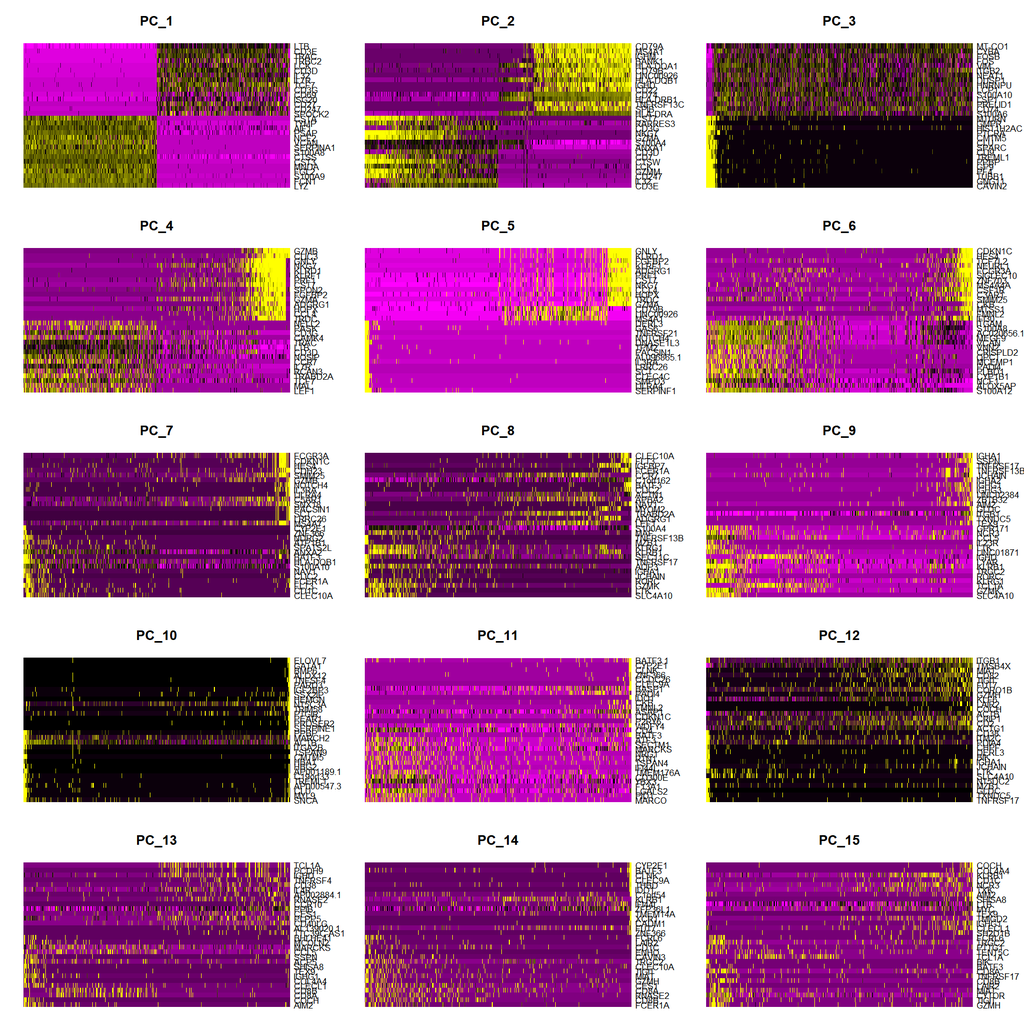

```r
DimHeatmap(pbmc, dims = 1:15, cells = 500, balanced = TRUE)
```

# Determine the ‘dimensionality’ of the dataset

To overcome the extensive technical noise in any single feature for scRNA-seq data, Seurat clusters cells based on their PCA scores, with each PC essentially representing a ‘metafeature’ that combines information across a correlated feature set. The top principal components therefore represent a robust compression of the dataset. However, how many componenets should we choose to include? 10? 20? 100?

In Macosko et al, the authors implemented a resampling test inspired by the JackStraw procedure. We randomly permute a subset of the data (1% by default) and rerun PCA, constructing a ‘null distribution’ of feature scores, and repeat this procedure. We identify ‘significant’ PCs as those who have a strong enrichment of low p-value features.

```r
# NOTE: This process can take a long time for big datasets, comment out for expediency. More
# approximate techniques such as those implemented in ElbowPlot() can be used to reduce
# computation time
pbmc <- JackStraw(pbmc, num.replicate = 100)
pbmc <- ScoreJackStraw(pbmc, dims = 1:20)
```

The JackStrawPlot function provides a visualization tool for comparing the distribution of p-values for each PC with a uniform distribution (dashed line). ‘Significant’ PCs will show a strong enrichment of features with low p-values (solid curve above the dashed line). In this case, it appears that there is a sharp drop-off in significance after the first 15 PCs.

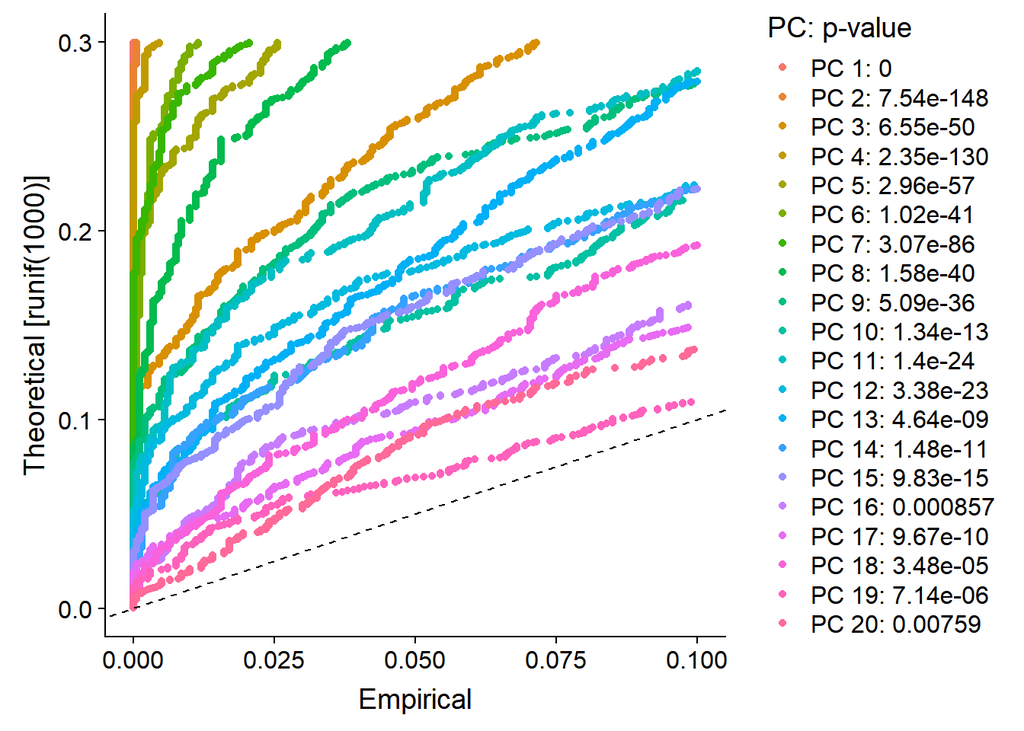

```r
JackStrawPlot(pbmc, dims = 1:20)
```

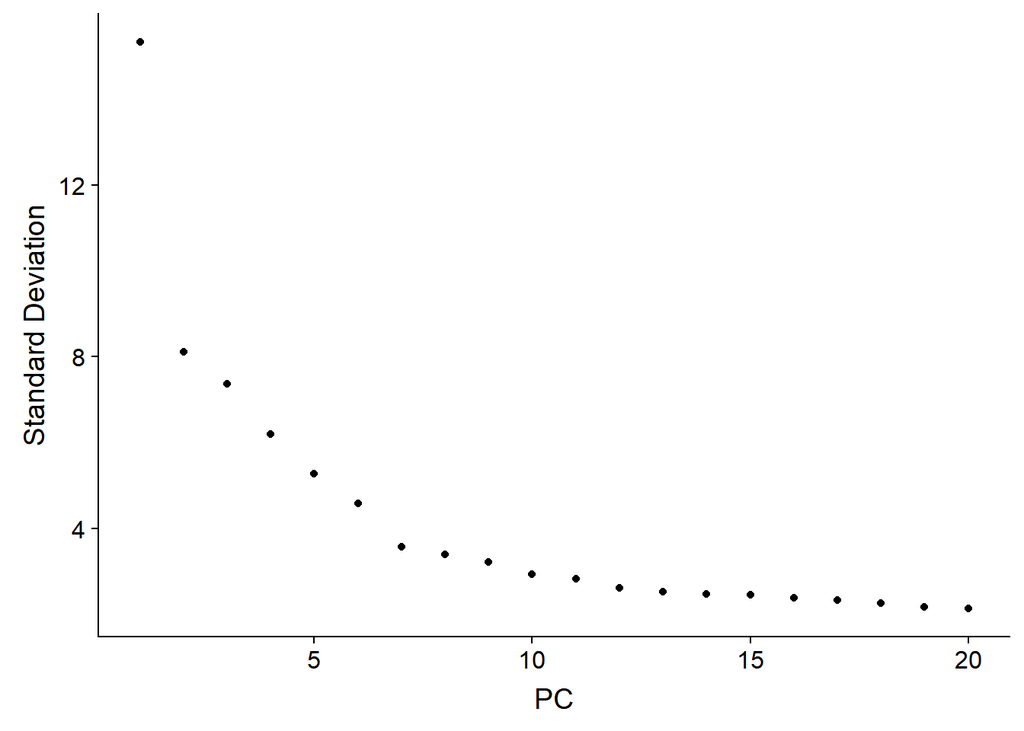

```r
ElbowPlot(pbmc)
```

Identifying the true dimensionality of a dataset – can be challenging/uncertain for the user. We therefore suggest these three approaches to consider. The first is more supervised, exploring PCs to determine relevant sources of heterogeneity, and could be used in conjunction with GSEA for example. The second implements a statistical test based on a random null model, but is time-consuming for large datasets, and may not return a clear PC cutoff. The third is a heuristic that is commonly used, and can be calculated instantly. In this example, all three approaches yielded similar results, but we might have been justified in choosing anything between PC 7-12 as a cutoff.

We choose 10 here, but we

- encourage users to repeat downstream analyses with a different number of PCs (10, 15, or even 50!). As you will observe, the results often do not differ dramatically.
- advise users to err on the higher side when choosing this parameter. For example, performing downstream analyses with only 5 PCs does signifcanltly and adversely affect results.

# Run Non-linear dimensional reduction

tSNE: T-distributed Stochastic Neighbor Embedding (t-SNE) is a machine learning algorithm for visualization. It is a nonlinear dimensionality reduction technique well-suited for embedding high-dimensional data for visualization in a low-dimensional space of two or three dimensions. Specifically, it models each high-dimensional object by a two- or three-dimensional point in such a way that similar objects are modeled by nearby points and dissimilar objects are modeled by distant points with high probability.

Seurat also offers an alternative non-linear dimensional reduction technique called **UMAP** to visualize and explore datasets. To use UMAP you need to install python on your machine and install the library [umap-learn](https://umap-learn.readthedocs.io/en/latest/). For the installation, you can also install the package via reticulate::py_install(packages = ‘umap-learn’).

As input to the UMAP and tSNE, we suggest using the same PCs as input to the clustering analysis.

```r
pbmc <- RunTSNE(object = pbmc,
                dims.use = 1:10)
```

## tSNE

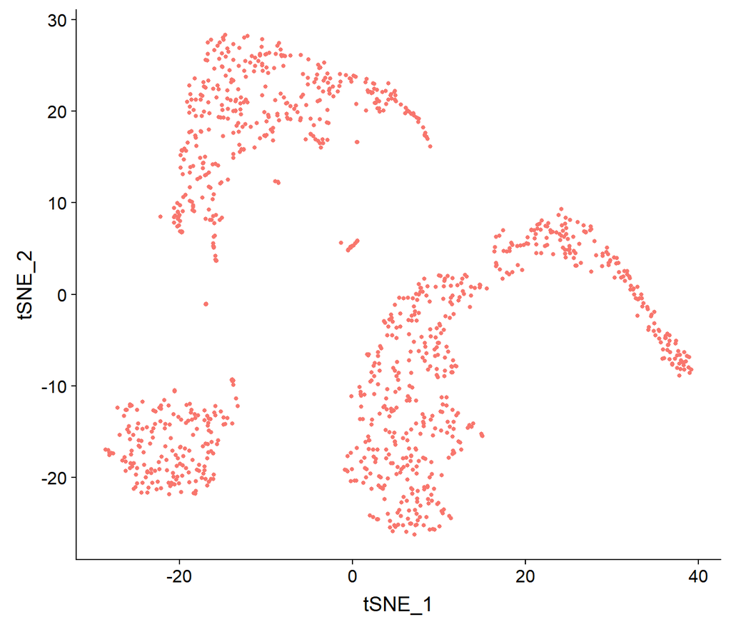

```r
DimPlot(object = pbmc, reduction = "tsne",label = FALSE)+NoLegend()
```

# Clustering

Seurat v3 applies a graph-based clustering approach, building upon initial strategies in (Macosko et al). Importantly, the distance metric which drives the clustering analysis (based on previously identified PCs) remains the same. However, the approach to partioning the cellular distance matrix into clusters has dramatically improved. The approach was heavily inspired by recent manuscripts which applied graph-based clustering approaches to scRNA-seq data [SNN-Cliq, Xu and Su, Bioinformatics, 2015] and CyTOF data [PhenoGraph, Levine et al., Cell, 2015]. Briefly, these methods embed cells in a graph structure - for example a K-nearest neighbor (KNN) graph, with edges drawn between cells with similar feature expression patterns, and then attempt to partition this graph into highly interconnected ‘quasi-cliques’ or ‘communities’.

As in PhenoGraph, the algorithm first constructs a KNN graph based on the euclidean distance in PCA space, and refines the edge weights between any two cells based on the shared overlap in their local neighborhoods (Jaccard similarity). This step is performed using the FindNeighbors function, and takes as input the previously defined dimensionality of the dataset (first 10 PCs).

To cluster the cells, we next apply modularity optimization techniques such as the Louvain algorithm (default) or SLM [SLM, Blondel et al., Journal of Statistical Mechanics], to iteratively group cells together, with the goal of optimizing the standard modularity function. The FindClusters function implements this procedure, and contains a resolution parameter that sets the ‘granularity’ of the downstream clustering, with increased values leading to a greater number of clusters. We find that setting this parameter between 0.3-1.0 typically returns good results for single-cell datasets of around 2K cells. Optimal resolution often increases for larger dataset containing more cell types or states.

```r
pbmc <- FindNeighbors(pbmc, dims = 1:10)
pbmc <- FindClusters(pbmc, resolution = 0.3)
```

```
## Modularity Optimizer version 1.3.0 by Ludo Waltman and Nees Jan van Eck
##
## Number of nodes: 1110
## Number of edges: 33598
##
## Running Louvain algorithm...
## Maximum modularity in 10 random starts: 0.9224
## Number of communities: 8
## Elapsed time: 0 seconds
```

```r
# Look at cluster IDs of the first 5 cells
head(Idents(pbmc), 5)
```

```
## AAACCCAAGGAGAGTA AAACGCTTCAGCCCAG AAAGAACAGACGACTG AAAGAACCAATGGCAG
##                0                2                4                4
## AAAGAACGTCTGCAAT
##                1
## Levels: 0 1 2 3 4 5 6 7
```

Now, the default identity of the cells has changed to the respective cluster IDs. Additionally, the clustering information can be accessed by:

```r
head(pbmc$RNA_snn_res.0.3)
```

```
## AAACCCAAGGAGAGTA AAACGCTTCAGCCCAG AAAGAACAGACGACTG AAAGAACCAATGGCAG
##                0                2                4                4
## AAAGAACGTCTGCAAT AAAGGATAGTAGACAT
##                1                2
## Levels: 0 1 2 3 4 5 6 7
```

**Number of cells per cluster:**

```r
table(pbmc$RNA_snn_res.0.3)
```

```
##
##   0   1   2   3   4   5   6   7
## 329 189 182 172 124  53  40  21
```

# Visualize Clustering on two-dimensional tSNE plot

## tSNE

### Combined plot

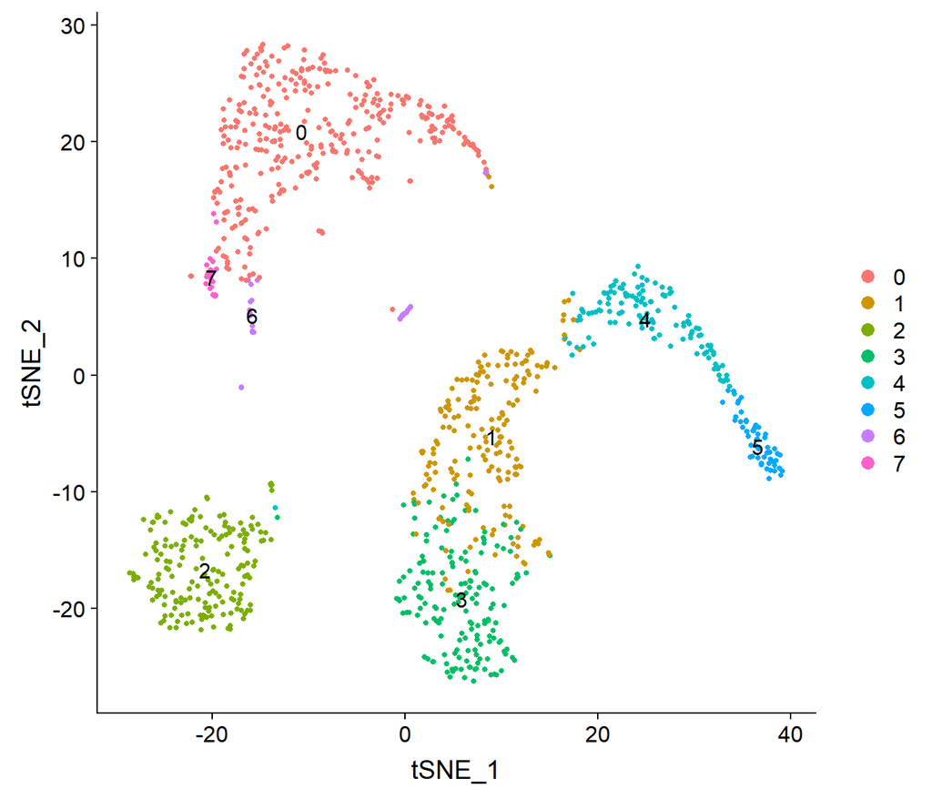

```r
DimPlot(object = pbmc, reduction = "tsne",label = TRUE)
```

### Split plot

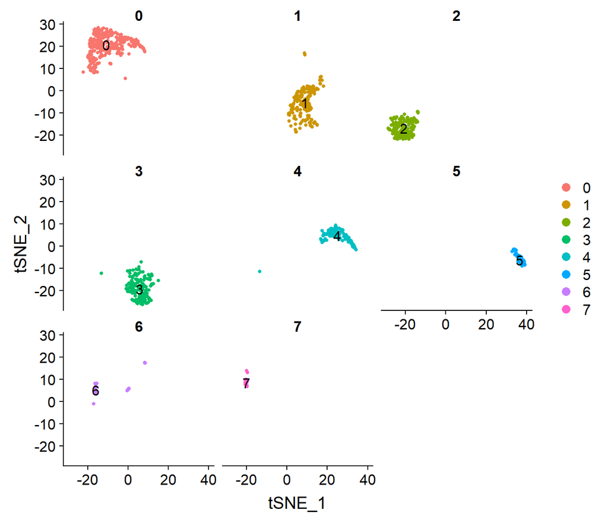

```r
DimPlot(object = pbmc, reduction = "tsne",label = TRUE, split.by = "RNA_snn_res.0.3")
```

## Compare clustering parameters

There are multiple parameters that greatly influence the clustering. To illustrate this we iterate through 3 different cluster algorithms & variable resolution settings!

Resolution: Value of the resolution parameter, use a value above (below) 1.0 if you want to obtain a larger (smaller) number of communities.

Clustering: Algorithm for modularity optimization

1. original Louvain algorithm
2. Louvain algorithm with multilevel refinement
3. SLM algorithm
4. Leiden algorithm (excluded here, since it requires python to be installed and the python library [leidenalg](https://pypi.org/project/leidenalg/))

```r
clustering_list <- list()
for(i in seq(from=0.3, to=0.7, by=0.1)){
  print(paste("Calculating clustering for resolution: ", i, sep=""))
  for(j in c(1:3)){
  print(paste("Using Clustering algorithm: ", j, sep=""))
  tmp <- pbmc
  tmp <- FindClusters(object = tmp, resolution = i, algorithm = j, verbose=FALSE)
  clustering_list[[length(clustering_list)+1]] <- DimPlot(object = tmp, reduction = "tsne", label = TRUE) + NoLegend() + ggtitle(paste("Algorithm:", j,", Resolution: ",i, sep=""))
  rm(tmp)
  }
}
```

```
## [1] "Calculating clustering for resolution: 0.3"
## [1] "Using Clustering algorithm: 1"
## [1] "Using Clustering algorithm: 2"
## [1] "Using Clustering algorithm: 3"
## [1] "Calculating clustering for resolution: 0.4"
## [1] "Using Clustering algorithm: 1"
## [1] "Using Clustering algorithm: 2"
## [1] "Using Clustering algorithm: 3"
## [1] "Calculating clustering for resolution: 0.5"
## [1] "Using Clustering algorithm: 1"
## [1] "Using Clustering algorithm: 2"
## [1] "Using Clustering algorithm: 3"
## [1] "Calculating clustering for resolution: 0.6"
## [1] "Using Clustering algorithm: 1"
## [1] "Using Clustering algorithm: 2"
## [1] "Using Clustering algorithm: 3"
## [1] "Calculating clustering for resolution: 0.7"
## [1] "Using Clustering algorithm: 1"
## [1] "Using Clustering algorithm: 2"
## [1] "Using Clustering algorithm: 3"
```

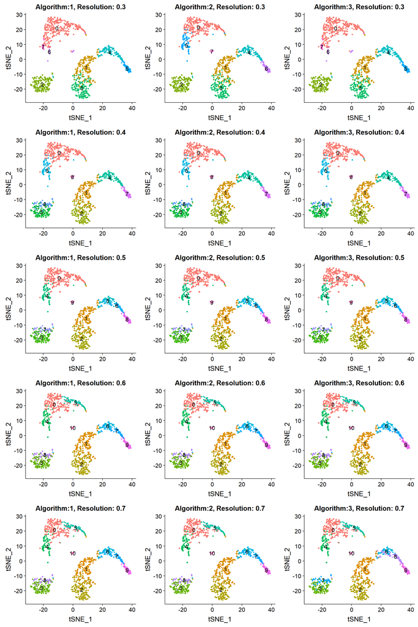

```r
rm(i,j)

CombinePlots(clustering_list,ncol=3)
```

# Finding differentially expressed features (cluster biomarkers)

Seurat can help you find markers that define clusters via differential expression. By default, it identifes positive and negative markers of a single cluster (specified in ident.1), compared to all other cells.

FindAllMarkers automates this process for all clusters, but you can also test groups of clusters vs. each other, or against all cells.

The min.pct argument requires a feature to be detected at a minimum percentage in either of the two groups of cells, and the thresh.test argument requires a feature to be differentially expressed (on average) by some amount between the two groups. You can set both of these to 0, but with a dramatic increase in time - since this will test a large number of features that are unlikely to be highly discriminatory. As another option to speed up these computations, max.cells.per.ident can be set. This will downsample each identity class to have no more cells than whatever this is set to. While there is generally going to be a loss in power, the speed increases can be significiant and the most highly differentially expressed features will likely still rise to the top.

```r
# find all markers of cluster 1
cluster1.markers <- FindMarkers(pbmc, ident.1 = 1, min.pct = 0.25)
head(cluster1.markers, n = 5)
```

|  | p_val | avg_logFC | pct.1 | pct.2 | p_val_adj |
| --- | --- | --- | --- | --- | --- |
| IL7R | 0 | 1.2886868 | 0.937 | 0.281 | 0 |
| IL32 | 0 | 1.0849751 | 0.968 | 0.314 | 0 |
| TRAC | 0 | 1.0057693 | 0.958 | 0.366 | 0 |
| LDHB | 0 | 0.8703965 | 0.979 | 0.710 | 0 |
| CD3D | 0 | 0.8155851 | 0.952 | 0.316 | 0 |

```r
# find all markers distinguishing cluster 5 from clusters 0 and 3
cluster5.markers <- FindMarkers(pbmc, ident.1 = 5, ident.2 = c(0, 3), min.pct = 0.25)
head(cluster5.markers, n = 5)
```

|  | p_val | avg_logFC | pct.1 | pct.2 | p_val_adj |
| --- | --- | --- | --- | --- | --- |
| HOPX | 0 | 2.511924 | 1.000 | 0.012 | 0 |
| KLRD1 | 0 | 2.653917 | 1.000 | 0.012 | 0 |
| CST7 | 0 | 2.697941 | 1.000 | 0.018 | 0 |
| KLRF1 | 0 | 2.263957 | 0.981 | 0.018 | 0 |
| PRF1 | 0 | 2.868008 | 1.000 | 0.022 | 0 |

```r
# find markers for every cluster compared to all remaining cells, report only the positive ones
pbmc.markers <- FindAllMarkers(pbmc, only.pos = TRUE, min.pct = 0.25, logfc.threshold = 0.25)
pbmc.markers %>% group_by(cluster) %>% top_n(n = 2, wt = avg_logFC)
```

| p_val | avg_logFC | pct.1 | pct.2 | p_val_adj | cluster | gene |
| --- | --- | --- | --- | --- | --- | --- |
| 0.0e+00 | 4.5913693 | 1.000 | 0.092 | 0.0000000 | 0 | S100A8 |
| 0.0e+00 | 4.6576291 | 0.997 | 0.146 | 0.0000000 | 0 | S100A9 |
| 0.0e+00 | 1.2886868 | 0.937 | 0.281 | 0.0000000 | 1 | IL7R |
| 0.0e+00 | 1.0849751 | 0.968 | 0.314 | 0.0000000 | 1 | IL32 |
| 0.0e+00 | 3.5977661 | 0.874 | 0.027 | 0.0000000 | 2 | IGHM |
| 0.0e+00 | 4.7726434 | 0.791 | 0.239 | 0.0000000 | 2 | IGKC |
| 0.0e+00 | 1.0061403 | 0.919 | 0.316 | 0.0000000 | 3 | TCF7 |
| 0.0e+00 | 0.9511175 | 0.907 | 0.485 | 0.0000000 | 3 | NOSIP |
| 0.0e+00 | 2.0584066 | 0.847 | 0.048 | 0.0000000 | 4 | GZMK |
| 0.0e+00 | 1.8959150 | 0.758 | 0.139 | 0.0000000 | 4 | KLRB1 |
| 0.0e+00 | 3.8790272 | 0.981 | 0.072 | 0.0000000 | 5 | GNLY |
| 0.0e+00 | 2.9298575 | 1.000 | 0.186 | 0.0000000 | 5 | NKG7 |
| 0.0e+00 | 4.8979252 | 0.375 | 0.041 | 0.0000000 | 6 | PPBP |
| 2.2e-06 | 4.0436961 | 0.500 | 0.238 | 0.0338955 | 6 | NRGN |
| 0.0e+00 | 2.5754270 | 1.000 | 0.046 | 0.0000000 | 7 | CDKN1C |
| 0.0e+00 | 2.8254062 | 1.000 | 0.096 | 0.0000000 | 7 | FCGR3A |

Seurat includes several tools for visualizing marker expression. VlnPlot (shows expression probability distributions across clusters), and FeaturePlot (visualizes gene expression on a tSNE or PCA plot) are our most commonly used visualizations.

## Dotplot

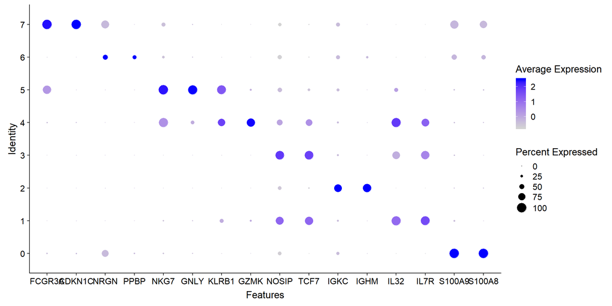

```r
pbmc.markers %>% group_by(cluster) %>% top_n(n = 2, wt = avg_logFC)->top2
DotPlot(object=pbmc,features = top2$gene,group.by = "RNA_snn_res.0.3")
```

## Violinplot

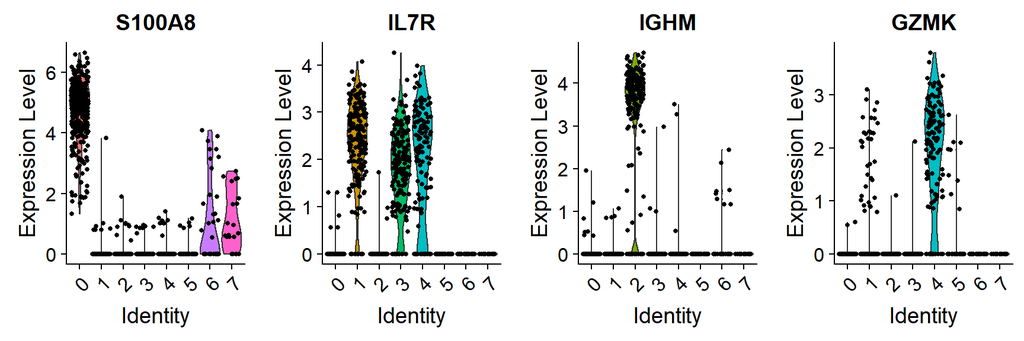

```r
VlnPlot(object = pbmc,
        features = c("S100A8", "IL7R","IGHM","GZMK"),ncol = 4)
```

## Plot marker expression on tSNE

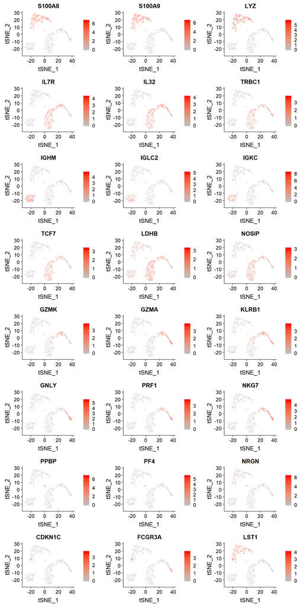

```r
pbmc.markers %>% group_by(cluster) %>% top_n(n = 3, wt = avg_logFC) -> top3

FeaturePlot(object = pbmc,
            features = top3$gene,
            cols = c("grey", "red"),
            reduction = "tsne",
            pt.size = 0.05,
            ncol=3)
```

## Heatmap

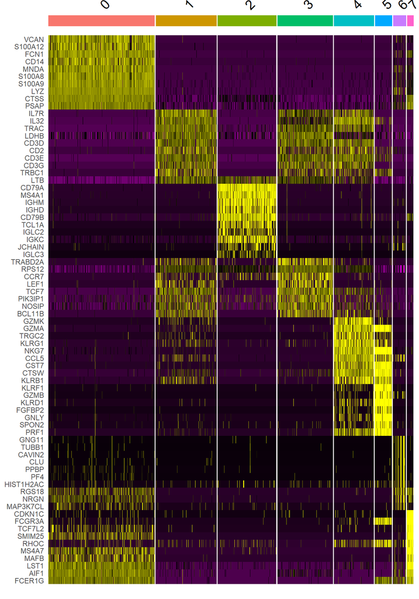

```r
top10 <- pbmc.markers %>% group_by(cluster) %>% top_n(n = 10, wt = avg_logFC)
DoHeatmap(pbmc, features = top10$gene) + NoLegend()
```

# Expression of well-characterized cell type markers

Fortunately in the case of this dataset, we can use well described markers to match the unbiased clustering results to known cell types:

| Markers | Cell Type |
| --- | --- |
| IL7R | CD4 T cells |
| CD14, LYZ | CD14+ Monocytes |
| MS4A1 | B cells |
| CD8A | CD8 T cells |
| FCGR3A, MS4A7 | FCGR3A+ Monocytes |
| GNLY, NKG7 | NK cells |
| FCER1A, CST3 | Dendritic Cells |
| PPBP | Megakaryocytes |

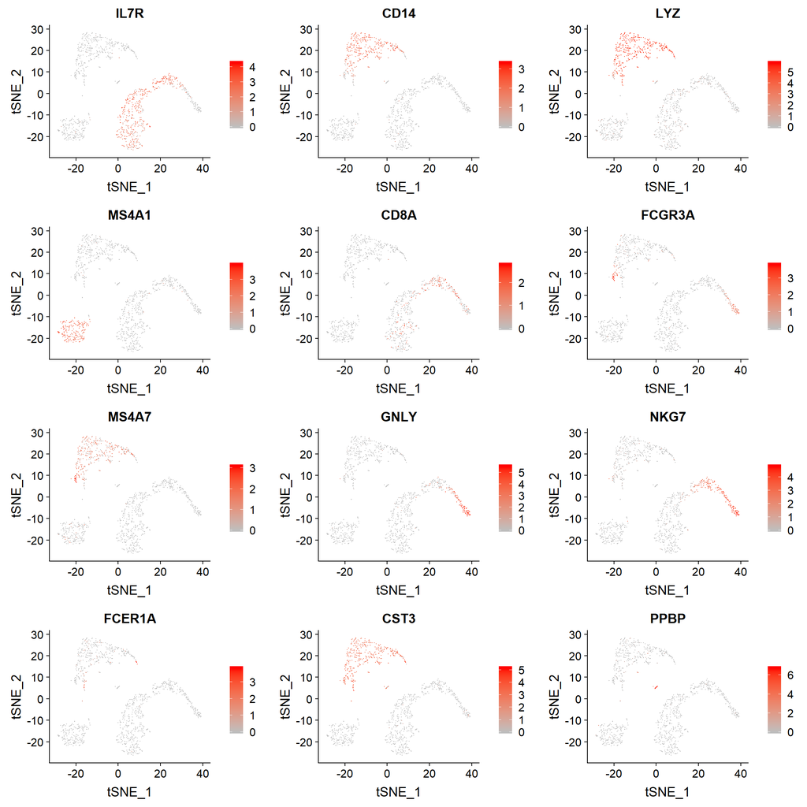

```r
FeaturePlot(object = pbmc,
            features = c("IL7R",
                         "CD14","LYZ",
                         "MS4A1",
                         "CD8A",
                         "FCGR3A","MS4A7",
                         "GNLY","NKG7",
                         "FCER1A","CST3",
                         "PPBP"),
            cols = c("grey", "red"),
            reduction = "tsne",
            pt.size = 0.05,
            ncol=3)
```

# Additional tasks:

Next, we define cells belonging to the myeloid or lymphoid lineage and practice some of the functions introduced earlier on this example:

We define cluster 0, 6 & 7 as myeloid and the rest as lympoid cells.

```r
pbmc$lineage <- ifelse(pbmc$RNA_snn_res.0.3 %in% c("0","6","7"),"myeloid","lymphoid")
```

Task: How many cells for each lineage does the data set contain?

```r
table(pbmc$lineage)
```

```
##
## lymphoid  myeloid
##      720      390
```

We now set the default identity of the cells to the lineage.

```r
Idents(object = pbmc) <- "lineage"
```

Task: Compare the distribution of unique gene counts for both lineages:

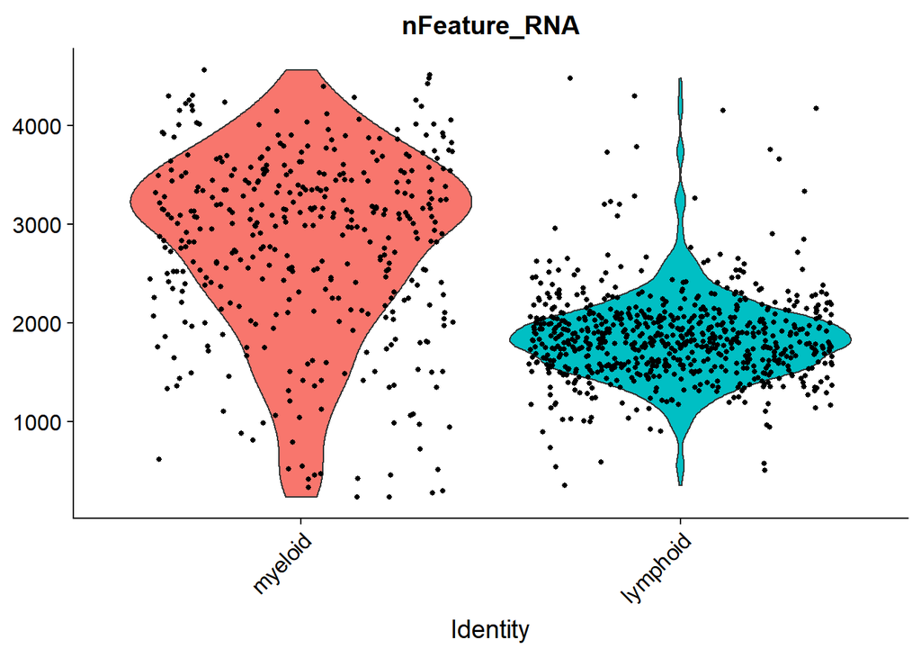

```r
VlnPlot(pbmc, features = c("nFeature_RNA"))+NoLegend()
```

Myeloid cells seem to express more genes than lympoid cells!

Task: Plot the dimensionality reduction plot (tSNE) with cells colored according to lineage and design a custom coloring for the two conditions. Remember, all Seurat plots are based on ggplot2 and accept additional input accordingly.

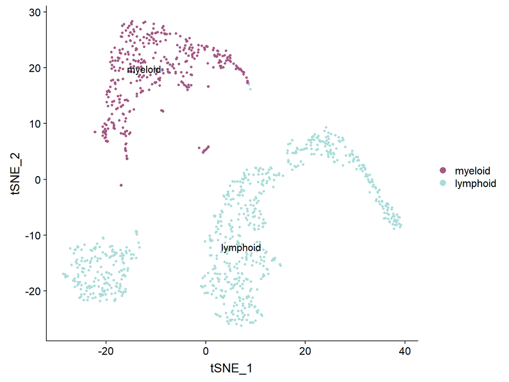

```r
DimPlot(object = pbmc, reduction = "tsne",label = TRUE)+scale_color_manual(values=c("myeloid" = "#A35884", "lymphoid" = "#A9DDD9"))
```

Task: Split the dimension reduction plot according to lineage and color by cluster:

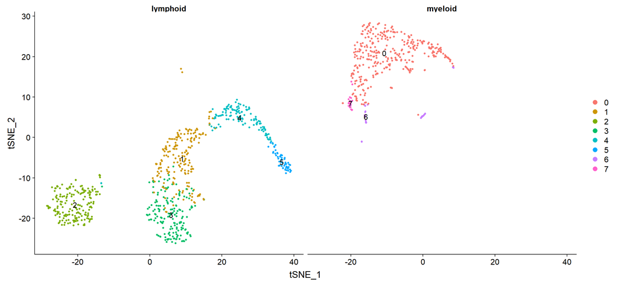

```r
DimPlot(object = pbmc, reduction = "tsne",group.by = "RNA_snn_res.0.3",split.by="lineage",label = TRUE)
```

Task: Calculate differentially expressed genes between myeloid and lymphoid cells and display a heatmap of the top 10 genes. In case you don’t like the Seurat coloring of the heatmap, try to change it.

```r
lineage.markers <- FindAllMarkers(pbmc,
                               only.pos = TRUE,
                               group.by = "lineage",
                               min.pct = 0.25)
lineage.markers %>% group_by(cluster) %>% top_n(n = 10, wt = avg_logFC) -> lineage.top10
lineage.top10
```

| p_val | avg_logFC | pct.1 | pct.2 | p_val_adj | cluster | gene |
| --- | --- | --- | --- | --- | --- | --- |
| 0.0000000 | 2.909363 | 0.985 | 0.024 | 0.0e+00 | myeloid | CST3 |
| 0.0000000 | 2.748166 | 0.921 | 0.008 | 0.0e+00 | myeloid | FCN1 |
| 0.0000000 | 2.527631 | 0.918 | 0.022 | 0.0e+00 | myeloid | MNDA |
| 0.0000000 | 4.775361 | 0.931 | 0.053 | 0.0e+00 | myeloid | S100A8 |
| 0.0000000 | 2.721893 | 0.887 | 0.007 | 0.0e+00 | myeloid | VCAN |
| 0.0000000 | 4.944836 | 0.941 | 0.104 | 0.0e+00 | myeloid | S100A9 |
| 0.0000000 | 4.380348 | 0.951 | 0.124 | 0.0e+00 | myeloid | LYZ |
| 0.0000000 | 2.959429 | 0.831 | 0.003 | 0.0e+00 | myeloid | S100A12 |
| 0.0000000 | 2.715776 | 0.967 | 0.475 | 0.0e+00 | myeloid | CTSS |
| 0.0000000 | 2.379768 | 0.682 | 0.012 | 0.0e+00 | myeloid | NRGN |
| 0.0000000 | 2.180852 | 0.862 | 0.226 | 0.0e+00 | lymphoid | LTB |
| 0.0000000 | 1.682645 | 0.751 | 0.026 | 0.0e+00 | lymphoid | TRBC2 |
| 0.0000000 | 1.847398 | 0.708 | 0.021 | 0.0e+00 | lymphoid | TRAC |
| 0.0000000 | 1.633951 | 0.696 | 0.023 | 0.0e+00 | lymphoid | CD3E |
| 0.0000000 | 2.165395 | 0.644 | 0.021 | 0.0e+00 | lymphoid | IL32 |
| 0.0000000 | 2.047839 | 0.597 | 0.015 | 0.0e+00 | lymphoid | IL7R |
| 0.0000000 | 1.630494 | 0.311 | 0.018 | 0.0e+00 | lymphoid | KLRB1 |
| 0.0000000 | 1.706575 | 0.267 | 0.021 | 0.0e+00 | lymphoid | CD79A |
| 0.0000000 | 2.018056 | 0.274 | 0.136 | 1.3e-06 | lymphoid | NKG7 |
| 0.0001133 | 3.437894 | 0.343 | 0.305 | 1.0e+00 | lymphoid | IGKC |

[output not shown]

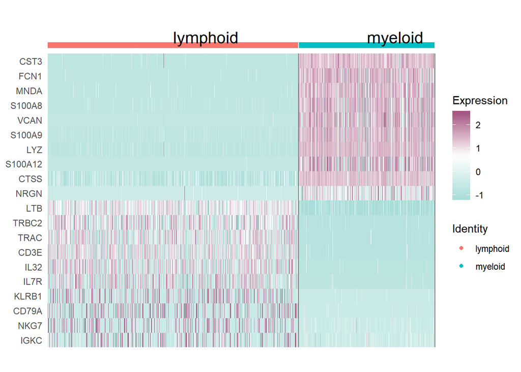

```r
DoHeatmap(pbmc, features = lineage.top10$gene,angle = 0)+
  scale_fill_gradientn(colors = c("#A9DDD9", "white", "#A35884"))
```

# Memory usage

```r
gc()
```

```
##            used  (Mb) gc trigger  (Mb) max used  (Mb)
## Ncells  2538439 135.6    7008187 374.3 13687867 731.1
## Vcells 34788701 265.5   72021064 549.5 93410661 712.7
```

# save Seurat object

```r
save(pbmc,file = paste("seuratObject_",Sys.Date(),".RData", sep=""))
```